# **Analysis of longitudinal data**

**Summary of week6 study**

- *In week6, I have studied the structure of longitudinal data which has repeated measures or a response variable may be recorded several different occasions over some period of time. In this case, we need to consider the within-subject variations and between-subject variation. Since it is very likely that the repeated measurements of the response variables will be correlated, we will need to assess the effects of this correlations and call the explanatory variables conditioning on this factor.*

```r
## Loading packages
library(dplyr)
```

```r
library(tidyr)
library(ggplot2)
library(GGally)
library(corrplot)
library(FactoMineR)
library(lme4)
```

## 1. Chapter8 - Graphical displays and summary measure approach

### 1.1 Read the data

In this part, we will use RATS data to demonstrate the graphical exploration of longitudinal data. Since this type of data is not independent, we will use general graphs to understand the data globally. The original data is download from [here](https://raw.githubusercontent.com/KimmoVehkalahti/MABS/master/Examples/data/rats.txt). We have pre-processed this wide type of data to long type. RATS data is collected from a nurtrition study conducted in three gorups of rats. The three groups were put on different diets and the weight (grams) of each rate has been measured.

```r
## read the data from our local folder
data_path <- "/Users/qingli/Documents/GitHub/IODS-project/Data/"
RATS <- read.csv(paste(data_path,"RATS.csv"))
RATSL<- read.csv(paste(data_path,"RATSL.csv"))
RATS$ID <- as.factor(RATS$ID)
RATS$Group<- as.factor(RATS$Group)

RATSL$ID <- as.factor(RATSL$ID)
RATSL$Group<- as.factor(RATSL$Group)

head(RATS)
```

```
##   ID Group WD1 WD8 WD15 WD22 WD29 WD36 WD43 WD44 WD50 WD57 WD64
## 1  1     1 240 250  255  260  262  258  266  266  265  272  278
## 2  2     1 225 230  230  232  240  240  243  244  238  247  245
## 3  3     1 245 250  250  255  262  265  267  267  264  268  269
## 4  4     1 260 255  255  265  265  268  270  272  274  273  275
## 5  5     1 255 260  255  270  270  273  274  273  276  278  280
## 6  6     1 260 265  270  275  275  277  278  278  284  279  281
```

```r
(RATS)
```

```
##    ID Group WD1 WD8 WD15 WD22 WD29 WD36 WD43 WD44 WD50 WD57 WD64
## 1   1     1 240 250  255  260  262  258  266  266  265  272  278
## 2   2     1 225 230  230  232  240  240  243  244  238  247  245
## 3   3     1 245 250  250  255  262  265  267  267  264  268  269
## 4   4     1 260 255  255  265  265  268  270  272  274  273  275
## 5   5     1 255 260  255  270  270  273  274  273  276  278  280
## 6   6     1 260 265  270  275  275  277  278  278  284  279  281
## 7   7     1 275 275  260  270  273  274  276  271  282  281  284
## 8   8     1 245 255  260  268  270  265  265  267  273  274  278
## 9   9     2 410 415  425  428  438  443  442  446  456  468  478
## 10 10     2 405 420  430  440  448  460  458  464  475  484  496
## 11 11     2 445 445  450  452  455  455  451  450  462  466  472
## 12 12     2 555 560  565  580  590  597  595  595  612  618  628
## 13 13     3 470 465  475  485  487  493  493  504  507  518  525
## 14 14     3 535 525  530  533  535  540  525  530  543  544  559
## 15 15     3 520 525  530  540  543  546  538  544  553  555  548
## 16 16     3 510 510  520  515  530  538  535  542  550  553  569
```

```r
head(RATSL)
```

```
##   ID Group  WD weight time
## 1  1     1 WD1    240    1
## 2  2     1 WD1    225    1
## 3  3     1 WD1    245    1
## 4  4     1 WD1    260    1
## 5  5     1 WD1    255    1
## 6  6     1 WD1    260    1
```

```r
dim(RATSL)
```

```
## [1] 176   5
```

```r
sum(RATSL$Group=="1")
```

```
## [1] 88
```

```r
sum(RATSL$Group=="2")
```

```
## [1] 44
```

```r
sum(RATSL$Group=="3")
```

```
## [1] 44
```

We have imblanced observations for the groups. There are 88 observations for Group1 and 44 each for Group2 & 3.

### 1.2 Graphic overview on unscaled data

We will first look at the raw data regardless of their correlations using the long form `RATSL`

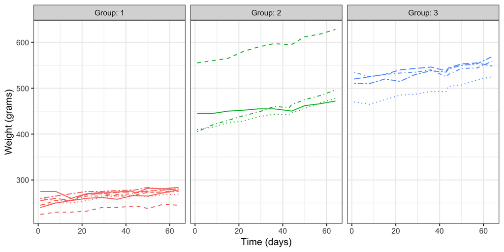

```r
ggplot(RATSL, aes(x = time, y = weight, linetype = ID,col=Group)) +
  geom_line() +  theme_bw() + xlab("Time (days)") + ylab("Weight (grams)") +
  scale_linetype_manual(values = rep(1:10, times=4)) +
  facet_grid(. ~ Group, labeller = label_both) +
  theme(legend.position = "none") +
  scale_y_continuous(limits = c(min(RATSL$weight), max(RATSL$weight)))
```

The above figure plots how does weight of individual rat response to different diets over 64 days (note that weight in WD1 is a baseline of the whole experiment). The overall of weight show an increasing trend for each rat in all groups. The within-group variations are varied, and those of group2 are in general bigger than those of group 1 & 3. Also, the rats with higher weights at time point 0 are typically weighted higher at the end time point regardless of the groups. By eye, the mean of weight in group1 is significantly different with that of group 2 and 3. It is hard to observe obvious difference in the later two groups.

### 1.3 Graphic overview on scaled data

Next, we standardize each observation (for example: minus the mean and divided by the SD of the observations within three groups for WD1 ) to check if the same pattern will be oberserved again.

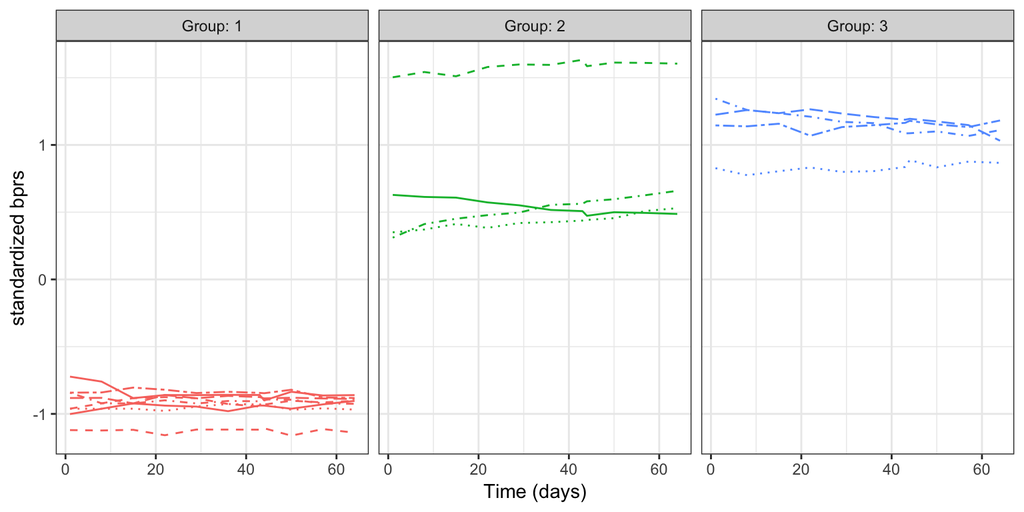

```r
RATSL_std <- RATSL %>% group_by(WD) %>% mutate(weight_std=(weight-mean(weight))/sd(weight)) %>% ungroup()
ggplot(RATSL_std, aes(x = time, y = weight_std, linetype = ID, col=Group)) +
  geom_line() + theme_bw() + xlab("Time (days)") + ylab("Weight (grams)") +
  scale_linetype_manual(values = rep(1:10, times=4)) +
  facet_grid(. ~ Group, labeller = label_both) +
   theme(legend.position = "none") +
  scale_y_continuous(name = "standardized bprs")
```

### 1.4 Compare the weight in each group

Next, we will use a box plot which combines all the subjects in each groups over different time points together to compare them.

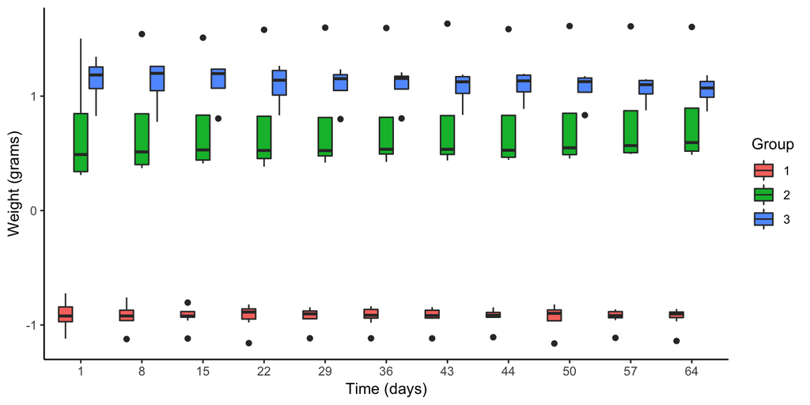

```r
ggplot(RATSL_std, aes(x = factor(time), y = weight_std, fill=Group)) +
  geom_boxplot() + xlab("Time (days)") + ylab("Weight (grams)") +
  theme_classic()
```

The baseline weight at WD1 are very different with each other with differenct intra-group variations as well. The rats’ average weight in group1 is the lowest, and that of group 3 is the highest. In terms of the intra-group variations, group2 is the biggest and group 1 is the smallest. From my own perspective, group 1 is more like a control experiments, because there is no big difference of weight changes in those rats. Again, we have observed outliers in each group, especially in Group 2 and the mean of weight in group1 is significantly different with that of group 2/3. There seems a difference in group 2 vs. group 3, but not that significant.

### 1.5 Compare the average weight in each group with standard error of mean

```r
## to see how many time points in the longitudinal data
n <- RATSL$time %>% unique() %>% length()
## summary the data to their means and sd(x)/sqrt(n) in each group defined by treatment vs. week
RATSS <- RATSL %>%
  group_by(Group, time) %>%
  summarise( mean = mean(weight), se = sd(weight)/sqrt(n) ) %>%
  ungroup()
RATSS
```

```
## # A tibble: 33 x 4
##    Group  time  mean    se
##    <fct> <int> <dbl> <dbl>
##  1 1         1  251.  4.59
##  2 1         8  255   3.95
##  3 1        15  254.  3.46
##  4 1        22  262.  4.10
##  5 1        29  265.  3.33
##  6 1        36  265   3.55
##  7 1        43  267.  3.30
##  8 1        44  267.  3.07
##  9 1        50  270.  4.39
## 10 1        57  272.  3.24
## # ... with 23 more rows
```

The above codes give us the summary table which has the average weight scores for the corresponding subjects of three groups within 64 days. We also have standard error of mean calculated using the standard deviation of those subjects’observations divided by the sqrt(n). n is number of the time points.

Then, we will have a graphic view of those resutls.

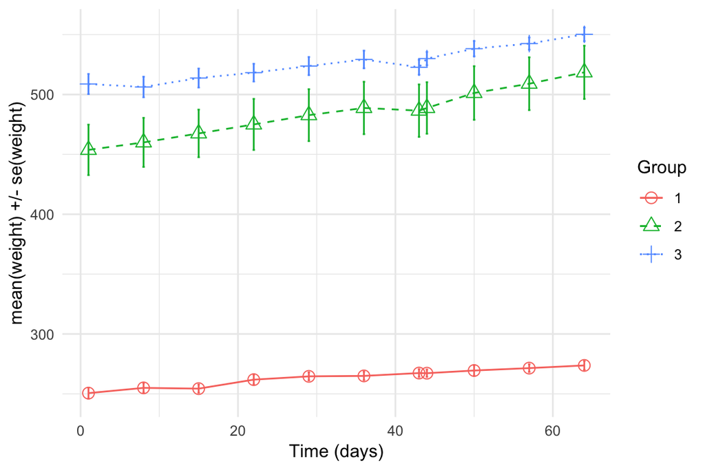

```r
ggplot(RATSS, aes(x = time, y = mean, linetype = Group, shape = Group, col=Group)) +
  geom_line() + xlab("Time (days)") +
  scale_linetype_manual(values = c(1,2,3)) + theme_minimal()+
  geom_point(size=3) +
  scale_shape_manual(values = c(1,2,3)) +
  geom_errorbar(aes(ymin=mean-se, ymax=mean+se, linetype="1"), width=0.3) +
  scale_y_continuous(name = "mean(weight) +/- se(weight)")
```

The variation in group 2 is much biggher might be cause by outliers. So, we will draw a box plot on the averaged observations to check it out.

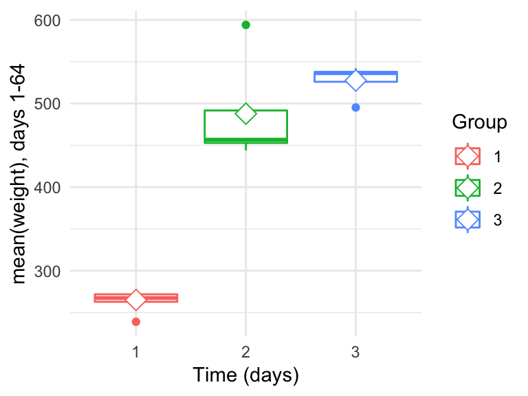

```r
## remove the baseline data
RATSL8S <- RATSL %>% filter (time>1) %>%
  group_by(Group, ID) %>%
  summarise( mean=mean(weight) ) %>%
  ungroup()
ggplot(RATSL8S, aes(x = Group, y = mean, col=Group)) +
  geom_boxplot() + theme_minimal() + xlab("Time (days)") +
  stat_summary(fun.y = "mean", geom = "point", shape=23, size=4, fill = "white") +
  scale_y_continuous(name = "mean(weight), days 1-64")
```

We can see the significant difference between the three groups. But it clearly shows there is an outlier in group 1, 2 and 3 . We will exclude them and see how does the plot look like.

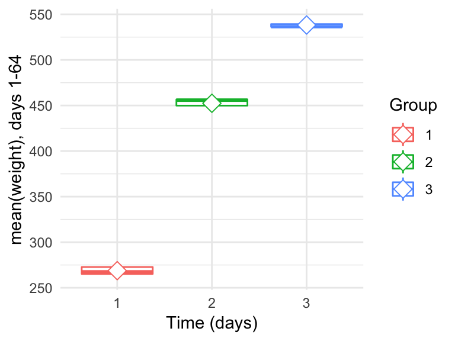

```r
G3_outlier <- min(RATSL8S$mean[RATSL8S$Group=="3"])
## to exculde the outliers
RATSL8S1 <- filter(RATSL8S,mean<550) %>% filter(mean > 250) %>% filter(mean !=G3_outlier)
ggplot(RATSL8S1, aes(x = Group, y = mean, col=Group)) +
  geom_boxplot() + theme_minimal() + xlab("Time (days)") +
  stat_summary(fun.y = "mean", geom = "point", shape=23, size=4, fill = "white") +
  scale_y_continuous(name = "mean(weight), days 1-64")
```

After remove the outliers, the variations in the three groups are much closer. We can even see a more significant difference between them.

Even we have explore the raw and average data using the graphs, there is difference in between groups. But it is still good to confirm it through statistic test.

### 1.6 Confirm the difference of mean by T-test.

There are three groups, we will extract data fro group1 & group2, group1 & group3 and group 2 & group3 to test the two-sample T test, respectively.

```r
# Perform a two-sample t-test
RATSL8S1_G1G2 <- RATSL8S1[RATSL8S1$Group!="3",]
t.test(mean ~ Group, data = RATSL8S1_G1G2, var.equal = TRUE)
```

```
##
##  Two Sample t-test
##
## data:  mean by Group
## t = -44.305, df = 8, p-value = 7.434e-11
## alternative hypothesis: true difference in means is not equal to 0
## 95 percent confidence interval:
##  -193.2012 -174.0845
## sample estimates:
## mean in group 1 mean in group 2
##        268.7571        452.4000
```

The mean of observations in group 1 is 268.7571 and 452.4000 in group 2. The T-test result (`_p_-value = 7.434e-11`) shows we should reject the null hypothesis which is the true difference in means in equal to 0. The T test result shows there is significant difference in group 1 and 2. Plus that the 95 CI interval (`(-193.2012 -174.0845)`) for the ture difference in mean is much smaller than 0, which also support the means of the two groups are different.

```r
# Perform a two-sample t-test
RATSL8S1_G1G3 <- RATSL8S1[RATSL8S1$Group!="2",]
t.test(mean ~ Group, data = RATSL8S1_G1G3, var.equal = TRUE)
```

```
##
##  Two Sample t-test
##
## data:  mean by Group
## t = -77.715, df = 8, p-value = 8.377e-13
## alternative hypothesis: true difference in means is not equal to 0
## 95 percent confidence interval:
##  -277.5065 -261.5125
## sample estimates:
## mean in group 1 mean in group 3
##        268.7571        538.2667
```

```r
# Perform a two-sample t-test
RATSL8S1_G2G3 <- RATSL8S1[RATSL8S1$Group!="1",]
t.test(mean ~ Group, data = RATSL8S1_G2G3, var.equal = TRUE)
```

```
##
##  Two Sample t-test
##
## data:  mean by Group
## t = -18.235, df = 4, p-value = 5.32e-05
## alternative hypothesis: true difference in means is not equal to 0
## 95 percent confidence interval:
##  -98.94088 -72.79246
## sample estimates:
## mean in group 2 mean in group 3
##        452.4000        538.2667
```

The T test p value for this group comparison is 5.32e-05 which is the least significant one.

Are they the real difference caused by different diet strategies? We still need to keep in mind that the baseline value in WD1 in significantly different in those groups. So our significance test needs to be done conditioning on this initial valuses.

### 1.7 Take baseline measurements in longitudinal studies into consideration

In longitudinal studies, the final results are normally correlated with the baseline value. We need to take that into cosideration when we are looking at the difference of the mean in the case-control group. Here we will add the baseline back and fit a linear model which takes the mean as the target variable and baseline and treatment with explanatory variables. Next, `ANOVA` will be used to see if there is any difference of the mean in there.

```r
RATSL8S2 <- RATSL8S %>% mutate(baseline = RATS$WD1)

# Fit the linear model with the mean as the response
fit <- lm(mean ~ baseline + Group, data = RATSL8S2)

# Compute the analysis of variance table for the fitted model with anova()
anova(fit)
```

```
## Analysis of Variance Table
##
## Response: mean
##           Df Sum Sq Mean Sq   F value   Pr(>F)
## baseline   1 253625  253625 1859.8201 1.57e-14 ***
## Group      2    879     439    3.2219  0.07586 .
## Residuals 12   1636     136
## ---
## Signif. codes:  0 '***' 0.001 '**' 0.01 '*' 0.05 '.' 0.1 ' ' 1
```

As we can see, the baseline is significantly associated with group means. Conditioning on the baseline value, we do not find a significant association between diet strategies and group means.

To conclude, for the longtitudinal data:

- The repeated measures within subjects are highly correlated.
- The large difference in initial baseline values has a big effect on the group mean difference test.
- Because the above two factors, the previous linear regression model will not be appropriate for this type of data. See the next part.

## 2. Chapter9: Linear Mixed Effects Models for Normal Reponse Variables for Longitudinal data.

##### The summary measure approach to the analysis of longitudinal data described in the previous chapter sometimes provides a useful first step in making in- ferences about the data, but it is really only ever a first step, and a more complete and a more appropriate analysis will involve fitting a suitable model to the data and estimating parameters that link the explanatory variables of interest to the repeated measures of the response variable.

### 2.1 Read the data

```r
## read the data from our local folder
data_path <- "/Users/qingli/Documents/GitHub/IODS-project/Data/"
BPRS <- read.csv(paste(data_path,"BPRS.csv"))
BPRSL <- read.csv(paste(data_path,"BPRSL.csv"))
BPRS$treatment <- as.factor(BPRS$treatment)
BPRS$subject<- as.factor(BPRS$subject)

BPRSL$treatment <- as.factor(BPRSL$treatment)
BPRSL$subject<- as.factor(BPRSL$subject)
head(BPRS)
```

```
##   treatment subject week0 week1 week2 week3 week4 week5 week6 week7 week8
## 1         1       1    42    36    36    43    41    40    38    47    51
## 2         1       2    58    68    61    55    43    34    28    28    28
## 3         1       3    54    55    41    38    43    28    29    25    24
## 4         1       4    55    77    49    54    56    50    47    42    46
## 5         1       5    72    75    72    65    50    39    32    38    32
## 6         1       6    48    43    41    38    36    29    33    27    25
```

```r
dim(BPRS)
```

```
## [1] 40 11
```

```r
head(BPRSL)
```

```
##   treatment subject weeks bprs week
## 1         1       1 week0   42    0
## 2         1       2 week0   58    0
## 3         1       3 week0   54    0
## 4         1       4 week0   55    0
## 5         1       5 week0   72    0
## 6         1       6 week0   48    0
```

```r
str(BPRSL)
```

```
## 'data.frame':    360 obs. of  5 variables:
##  $ treatment: Factor w/ 2 levels "1","2": 1 1 1 1 1 1 1 1 1 1 ...
##  $ subject  : Factor w/ 20 levels "1","2","3","4",..: 1 2 3 4 5 6 7 8 9 10 ...
##  $ weeks    : Factor w/ 9 levels "week0","week1",..: 1 1 1 1 1 1 1 1 1 1 ...
##  $ bprs     : int  42 58 54 55 72 48 71 30 41 57 ...
##  $ week     : int  0 0 0 0 0 0 0 0 0 0 ...
```

```r
dim(BPRSL)
```

```
## [1] 360   5
```

### 2.2 Graphic overview of the data

Before we fit any models for the data, it is always good to explore the relationships between the variables. Let’s assume they are independent.

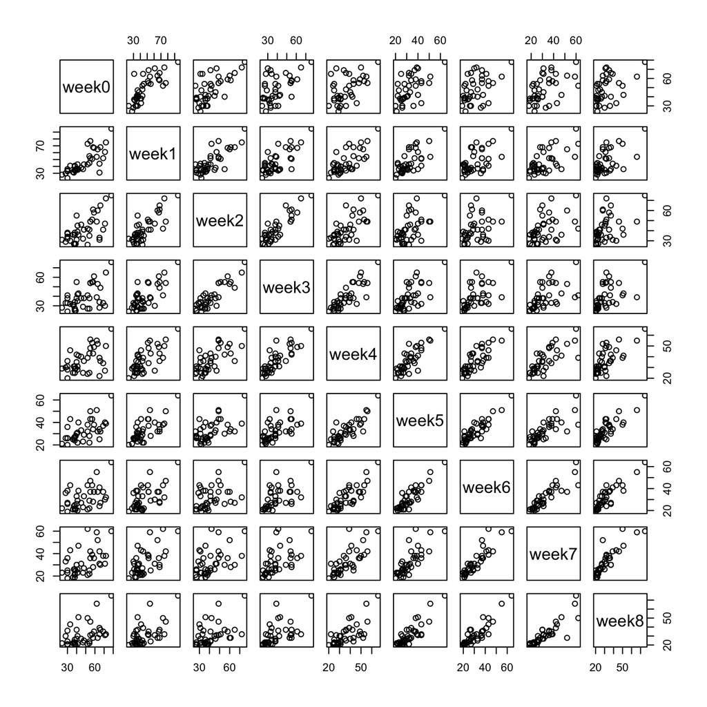

```r
pairs(BPRS[,3:11])
```

By eye, the BPRS scores are positively correlated with each other for different weeks.

```r
cor_matrix <- cor(BPRS[,3:11])
mean(cor_matrix)
```

```
## [1] 0.7218064
```

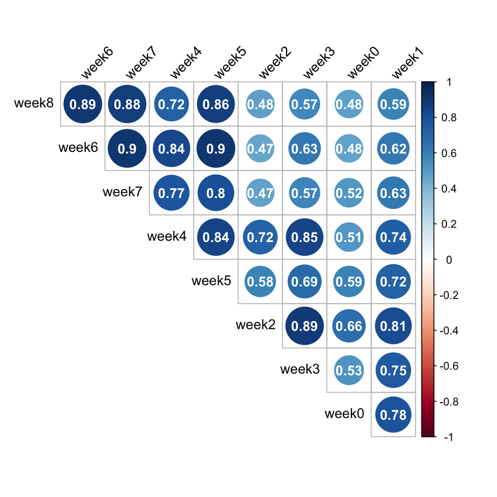

```r
corrplot(cor_matrix,method="circle",
         type="upper", order="hclust",
         addCoef.col = "white", # Add coefficient of correlation
         tl.col="black", tl.srt=45, #Text label color and rotation
         # Combine with significance
         # hide correlation coefficient on the principal diagonal
         diag=FALSE)
```

The correlation plot above shows the same result. Quantitatively, the overall average coefficient is 0.72, and the lowest and highest ones are about 0.47 and 0.9, respectively. The result simply shows the the strong correlation structure of longitudinal data.

**We will next have a brief look of the raw data before and after standarlization.**

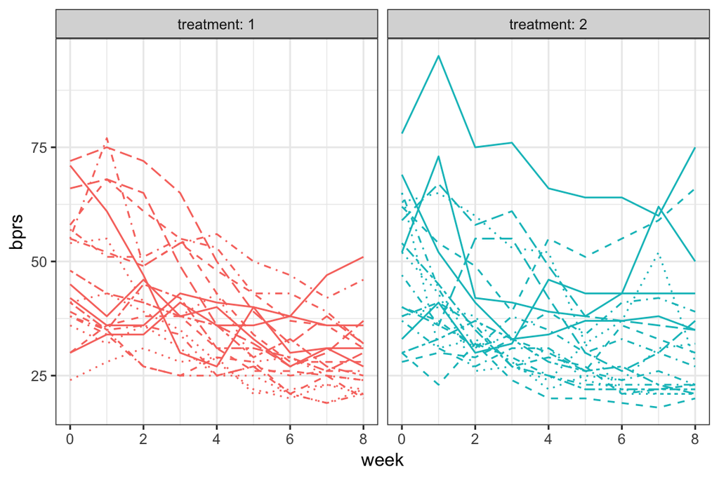

```r
##Standarlize the data and visualize the raw data.
ggplot(BPRSL, aes(x = week, y = bprs, linetype = subject,col=treatment)) +
  geom_line() + theme_bw()+
  scale_linetype_manual(values = rep(1:10, times=4)) +
  facet_grid(. ~ treatment, labeller = label_both) +
  theme(legend.position = "none") +
  scale_y_continuous(limits = c(min(BPRSL$bprs), max(BPRSL$bprs)))
```

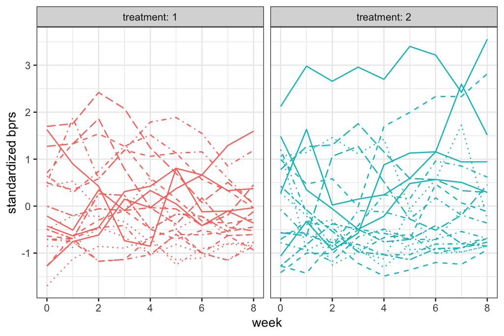

```r
BPRSL <- BPRSL %>%
  group_by(week) %>%
  mutate(stdbprs = (bprs-mean(bprs))/sd(bprs)) %>% ungroup()

# Plot again with the standardised bprs
ggplot(BPRSL, aes(x = week, y = stdbprs, linetype = subject,col=treatment)) +
  geom_line() + theme_bw()+
  scale_linetype_manual(values = rep(1:10, times=4)) +
  facet_grid(. ~ treatment, labeller = label_both) +
   theme(legend.position = "none") +
  scale_y_continuous(name = "standardized bprs")
```

As we can see the changes before and after the standarlization, the within-group variations are turning much smaller for the later one. Unlike our RATS data, we cannot see any differences between two treatment groups.

### 2.3 Regression models application on longitudinal data.

Our goal in this stduy is to find if `treatment` is an explanatory variable for `BPRS` score. We will first treat the data as independent to check the result, which is of course not the case here.

```r
BPRS_reg <- lm(bprs ~ week+treatment,BPRSL)
summary(BPRS_reg)
```

```
##
## Call:
## lm(formula = bprs ~ week + treatment, data = BPRSL)
##
## Residuals:
##     Min      1Q  Median      3Q     Max
## -22.454  -8.965  -3.196   7.002  50.244
##
## Coefficients:
##             Estimate Std. Error t value Pr(>|t|)
## (Intercept)  46.4539     1.3670  33.982   <2e-16 ***
## week         -2.2704     0.2524  -8.995   <2e-16 ***
## treatment2    0.5722     1.3034   0.439    0.661
## ---
## Signif. codes:  0 '***' 0.001 '**' 0.01 '*' 0.05 '.' 0.1 ' ' 1
##
## Residual standard error: 12.37 on 357 degrees of freedom
## Multiple R-squared:  0.1851, Adjusted R-squared:  0.1806
## F-statistic: 40.55 on 2 and 357 DF,  p-value: < 2.2e-16
```

The linear model tells us `week` is significantly associated with BPRS score, but treatment 2 is not. Since this model assumes the indenpendence of the measures of BPRS, we have already shown they are highly correlated. So we will move to the mixed effects linear models.

**Random intercept model**

```r
BPRS_ref_RI <- lmer(bprs ~ week + treatment + (1 | subject), data = BPRSL, REML = FALSE)
summary(BPRS_ref_RI)
```

```
## Linear mixed model fit by maximum likelihood  ['lmerMod']
## Formula: bprs ~ week + treatment + (1 | subject)
##    Data: BPRSL
##
##      AIC      BIC   logLik deviance df.resid
##   2748.7   2768.1  -1369.4   2738.7      355
##
## Scaled residuals:
##     Min      1Q  Median      3Q     Max
## -3.0481 -0.6749 -0.1361  0.4813  3.4855
##
## Random effects:
##  Groups   Name        Variance Std.Dev.
##  subject  (Intercept)  47.41    6.885
##  Residual             104.21   10.208
## Number of obs: 360, groups:  subject, 20
##
## Fixed effects:
##             Estimate Std. Error t value
## (Intercept)  46.4539     1.9090  24.334
## week         -2.2704     0.2084 -10.896
## treatment2    0.5722     1.0761   0.532
##
## Correlation of Fixed Effects:
##            (Intr) week
## week       -0.437
## treatment2 -0.282  0.000
```

Fitting a random intercept model allows the linear regression fit different intercepts to each subject. The intercepts are random variables are representing random differences between groups. Under this model, the constant regression coefficient is assumed, which means the correlation within subjects is the same for samples close or distant in time. It is not the case for most of the longitudinal data, whose samples from closer time points are more correlated with those from distant time points.

**Random Intercept and Random Slope Model**

```r
BPRS_ref_RIS <- lmer(bprs ~ week + treatment + (week | subject), data = BPRSL, REML = FALSE)
summary(BPRS_ref_RIS)
```

```
## Linear mixed model fit by maximum likelihood  ['lmerMod']
## Formula: bprs ~ week + treatment + (week | subject)
##    Data: BPRSL
##
##      AIC      BIC   logLik deviance df.resid
##   2745.4   2772.6  -1365.7   2731.4      353
##
## Scaled residuals:
##     Min      1Q  Median      3Q     Max
## -2.8919 -0.6194 -0.0691  0.5531  3.7976
##
## Random effects:
##  Groups   Name        Variance Std.Dev. Corr
##  subject  (Intercept) 64.8202  8.0511
##           week         0.9608  0.9802   -0.51
##  Residual             97.4307  9.8707
## Number of obs: 360, groups:  subject, 20
##
## Fixed effects:
##             Estimate Std. Error t value
## (Intercept)  46.4539     2.1052  22.066
## week         -2.2704     0.2977  -7.626
## treatment2    0.5722     1.0405   0.550
##
## Correlation of Fixed Effects:
##            (Intr) week
## week       -0.582
## treatment2 -0.247  0.000
```

Fitting a random intercept and a randome slope model allows the linear regression fit different intercepts and different slopes of each subject. This model is not only holding the random intercept but also have a changable coefficients, which means the correlation within subjects is the different for samples close or distant in time. Obviously, it is much closer to the real case.

**Compare the above two models**

```r
anova(BPRS_ref_RI, BPRS_ref_RIS)
```

```
## Data: BPRSL
## Models:
## BPRS_ref_RI: bprs ~ week + treatment + (1 | subject)
## BPRS_ref_RIS: bprs ~ week + treatment + (week | subject)
##              Df    AIC    BIC  logLik deviance  Chisq Chi Df Pr(>Chisq)
## BPRS_ref_RI   5 2748.7 2768.1 -1369.4   2738.7
## BPRS_ref_RIS  7 2745.4 2772.6 -1365.7   2731.4 7.2721      2    0.02636 *
## ---
## Signif. codes:  0 '***' 0.001 '**' 0.01 '*' 0.05 '.' 0.1 ' ' 1
```

There is a slightly significant differenct between two models given the Chi squre test result, which means we should introduce random slope in our model.

```r
BPRS_ref_RIS_interaction <- lmer(bprs ~ week + treatment + (week | treatment), data = BPRSL, REML = FALSE)
summary(BPRS_ref_RIS_interaction)
```

```
## Linear mixed model fit by maximum likelihood  ['lmerMod']
## Formula: bprs ~ week + treatment + (week | treatment)
##    Data: BPRSL
##
##      AIC      BIC   logLik deviance df.resid
##   2843.3   2870.5  -1414.7   2829.3      353
##
## Scaled residuals:
##     Min      1Q  Median      3Q     Max
## -1.8252 -0.7277 -0.2586  0.5697  4.0818
##
## Random effects:
##  Groups    Name        Variance  Std.Dev. Corr
##  treatment (Intercept) 2.820e-02  0.16794
##            week        1.763e-03  0.04199 -1.00
##  Residual              1.516e+02 12.31302
## Number of obs: 360, groups:  treatment, 2
##
## Fixed effects:
##             Estimate Std. Error t value
## (Intercept)  46.4539     1.3664  33.997
## week         -2.2704     0.2531  -8.971
## treatment2    0.5722     1.2979   0.441
##
## Correlation of Fixed Effects:
##            (Intr) week
## week       -0.741
## treatment2 -0.475  0.000
```

The fixed effects haven’t changed that much, but the random effects have changed quite a lot. The variance could not be explained too much by introducing random effects of both treatment and week.

Let’s compare the last two models using **ANOVA**

```r
anova(BPRS_ref_RIS, BPRS_ref_RIS_interaction)
```

```
## Data: BPRSL
## Models:
## BPRS_ref_RIS: bprs ~ week + treatment + (week | subject)
## BPRS_ref_RIS_interaction: bprs ~ week + treatment + (week | treatment)
##                          Df    AIC    BIC  logLik deviance Chisq Chi Df
## BPRS_ref_RIS              7 2745.4 2772.6 -1365.7   2731.4
## BPRS_ref_RIS_interaction  7 2843.3 2870.5 -1414.7   2829.3     0      0
##                          Pr(>Chisq)
## BPRS_ref_RIS
## BPRS_ref_RIS_interaction          1
```

From the above results, we should stay with BPRS_ref_RIS, the no interaction one.

**Plot the original and fitted values using BPRS_ref_RIS model for BPRS data**

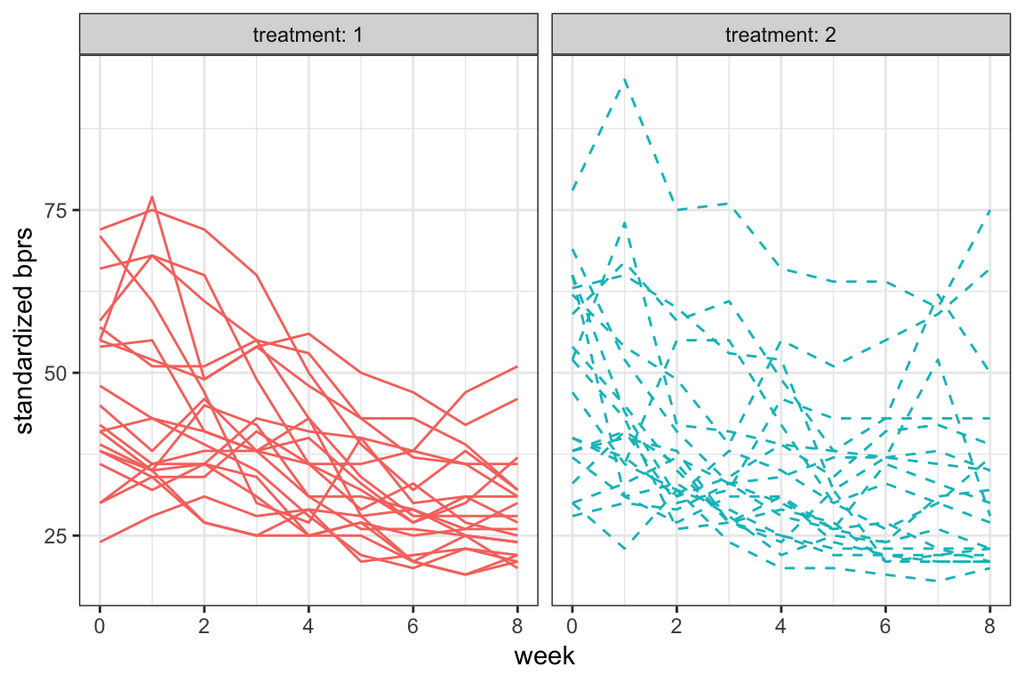

```r
ggplot(BPRSL, aes(x = week, y = bprs, group = subject, linetype = treatment,col=treatment)) +
  geom_line() + theme_bw()+
  scale_linetype_manual(values = rep(1:2, times=4)) +
  facet_grid(. ~ treatment, labeller = label_both) +
   theme(legend.position = "none") +
  scale_y_continuous(name = "standardized bprs")
```

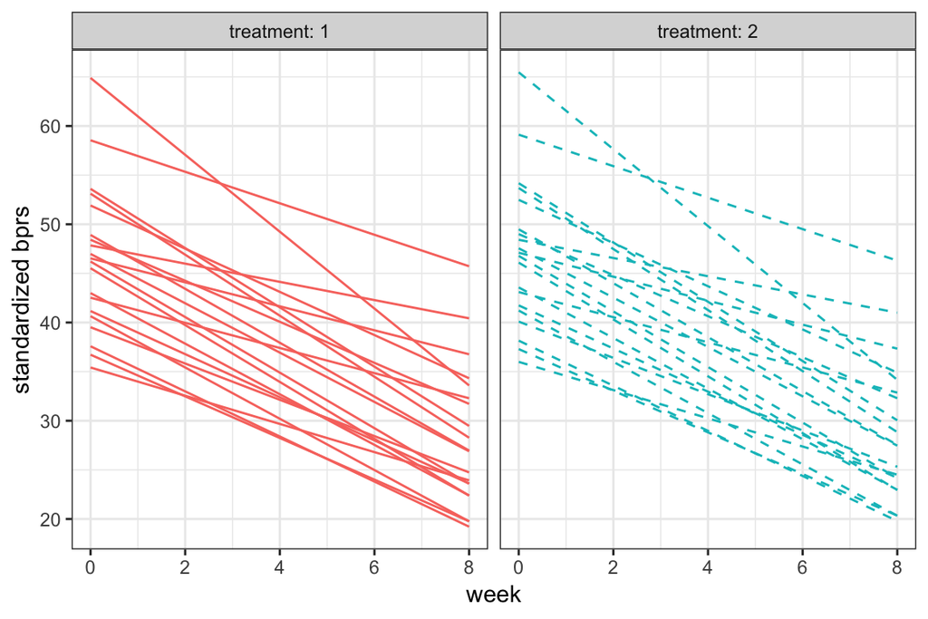

```r
# Create a vector of the fitted values
Fitted <- fitted(BPRS_ref_RIS,BPRSL$week,BPRSL$treatment)

# Create a new column fitted to RATSL
BPRSL<-mutate(BPRSL,fitted=Fitted)

ggplot(BPRSL, aes(x = week, y = fitted, group = subject, linetype = treatment,col=treatment)) +
  geom_line() + theme_bw()+
  scale_linetype_manual(values = rep(1:2, times=4)) +
  facet_grid(. ~ treatment, labeller = label_both) +
   theme(legend.position = "none") +
  scale_y_continuous(name = "standardized bprs")
```

The two figures have compared the original and fitted bprs values by the selected model (random intercept and random slope) for each subject along different time points.